# 2장. 추천 시스템에서 사용되는 데이터 마이닝 기법

## 1. 데이터 분석 문제 해결하기

1. 비즈니스의 문제 파악하기.
2. 해당 분야 전문가의 도움으로 비즈니스의 문제 영역 이해하기
3. 데이터 출처를 파악하고 분석에 적절한 변수 파악하기
4. 결측치(Missing Value) 제거, 정성적과 정량적 변수 구분하기, 데이터 변환과 같은 데이터 전처리나 데이터 정제(Data Cleaning) 작업하기.
5. 데이터를 이해하기 위해 상자그림이나 히스토그램을 통한 탐색적 분석하기.
6. 데이터의 성격을 이해하기 위해 변수 간의 평균, 중앙값, 최빈값, 분산, 표준편차, 상관관계, 공분산 등의 기본적인 통계치 확인하기
7. 데이터를 트레이닝 데이터와 테스트 데이터로 나누고 트레이닝 데이터를 가지고 머신 러닝 알고리즘들을 적용한 모델에 교차검증(Cross validation) 기법 적용하기
8. 새로운 모델을 평가하기 위해 테스트 데이터를 이용해 모델 검증. 검증 단계의 결과에 따라 모델 성능 개량 진행하기
9. 결과를 시각화하고 실시간 예측을 위해 모델 배포하기.
- 다음 그림은 데이터 분석 문제를 해결하는 방법을 보여준다.

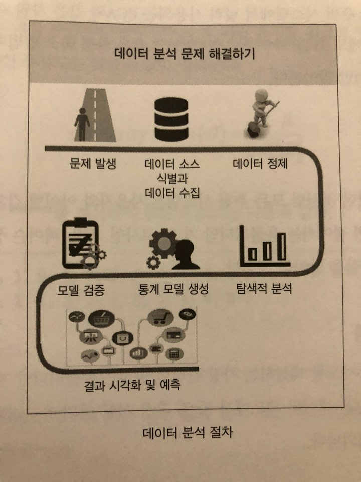

데이터 분석 절차.

## 2. 데이터 전처리 기법

데이터 전처리 과정은 데이터 분석 문제를 해결하는 과정에서 매우 중요한 절차다. 모델의 정확도는 대부분 데이터의 품질에 따라 달라진다. 일반적으로 데이터 정제, 변환, 결측치 확인, 처리 방법이 데이터 전처리 과정에 해당한다.

이러한 기법들은 유사도 측정(유클리디안, 코사인 거리, 피어슨 상관계수)과 추천 시스템에서 널리 사용되는 PCA 와 같은 차원 축소 기법들을 포함한다.

### 2.1 유사도 측정

**모든 추천 시스템은 사용자와 아이템 간의 유사도를 고려해 작동한다.**

#### 2.1.1 유클리디안 거리

두 아이템 간의 유사도를 계산하는 가장 간단한 방법은 유클리디안 거리(Euclidean Distance) 이다. 데이터 셋에서 두 점 혹은 사물 간의 유클리디안 거리는 다음과 같은 식으로 정의된다.

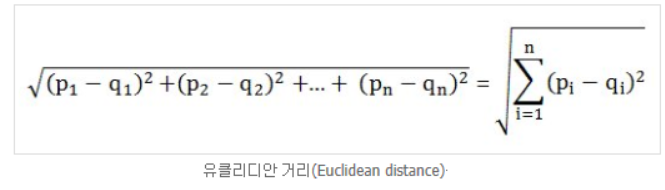

##### 유클리디안 거리 계산 코드

```r
x1 <- rnorm(30)
x2 <- rnorm(30)
Euc_dist <- dist(rbind(x1,x2), method="euclidean")
```

#### 2.1.2 코사인 거리

코사인 유사도는 내적 공간(Inner Product Space)의 두 벡터 유사도 값으로 벡터 사이의 코사인 값이다. 코사인 유사도는 다음과 같이 정의된다.

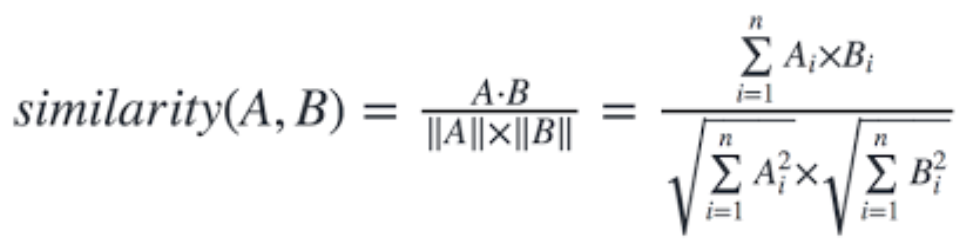

코사인 거리를 계산하기 위한 R코드는 다음과 같다.

```r
vec1 <- c(1, 1, 1, 0, 0, 0, 0, 0, 0, 0, 0, 0)
vec2 <- c(0, 0, 1, 1, 1, 1, 1, 0, 1, 0, 0, 0)
if(!"lsa" %in% rownames(installed.packages())){install.packages("lsa")}
library(lsa)
cosine(vec1, vec2)
```

```
##           [,1]
## [1,] 0.2357023
```

#### 2.1.3 피어슨 상관 계수

두 상품 간의 유사도는 변수들 간의 상관관계를 구하는 것으로도 얻을 수 있다. 피어슨 상관 계수(Pearson Correlation)는 두 변수의 공분산 값을 변수들의 표준 편차의 곱으로 나눠 구하며 가장 널리 사용되는 상관 계수 중 하나다.

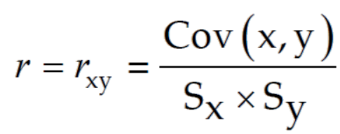

R 소스 코드는 다음과 같다.

```r
Coef = cor(mtcars, method="pearson")
Coef # 모든 변수들 간의 피어슨 상관 계수
```

```
##             mpg        cyl       disp         hp        drat         wt
## mpg   1.0000000 -0.8521620 -0.8475514 -0.7761684  0.68117191 -0.8676594
## cyl  -0.8521620  1.0000000  0.9020329  0.8324475 -0.69993811  0.7824958
## disp -0.8475514  0.9020329  1.0000000  0.7909486 -0.71021393  0.8879799
## hp   -0.7761684  0.8324475  0.7909486  1.0000000 -0.44875912  0.6587479
## drat  0.6811719 -0.6999381 -0.7102139 -0.4487591  1.00000000 -0.7124406
## wt   -0.8676594  0.7824958  0.8879799  0.6587479 -0.71244065  1.0000000
## qsec  0.4186840 -0.5912421 -0.4336979 -0.7082234  0.09120476 -0.1747159
## vs    0.6640389 -0.8108118 -0.7104159 -0.7230967  0.44027846 -0.5549157
## am    0.5998324 -0.5226070 -0.5912270 -0.2432043  0.71271113 -0.6924953
## gear  0.4802848 -0.4926866 -0.5555692 -0.1257043  0.69961013 -0.5832870
## carb -0.5509251  0.5269883  0.3949769  0.7498125 -0.09078980  0.4276059
##             qsec         vs          am       gear        carb
## mpg   0.41868403  0.6640389  0.59983243  0.4802848 -0.55092507
## cyl  -0.59124207 -0.8108118 -0.52260705 -0.4926866  0.52698829
## disp -0.43369788 -0.7104159 -0.59122704 -0.5555692  0.39497686
## hp   -0.70822339 -0.7230967 -0.24320426 -0.1257043  0.74981247
## drat  0.09120476  0.4402785  0.71271113  0.6996101 -0.09078980
## wt   -0.17471588 -0.5549157 -0.69249526 -0.5832870  0.42760594
## qsec  1.00000000  0.7445354 -0.22986086 -0.2126822 -0.65624923
## vs    0.74453544  1.0000000  0.16834512  0.2060233 -0.56960714
## am   -0.22986086  0.1683451  1.00000000  0.7940588  0.05753435
## gear -0.21268223  0.2060233  0.79405876  1.0000000  0.27407284
## carb -0.65624923 -0.5696071  0.05753435  0.2740728  1.00000000
```

경험적 연구에서 볼 때 피어슨 상관 계수는 다른 유사도 측정 방식보다 **사용자 기반 협업 필터링 추천 시스템**에서 뛰어난 성능을 보인다. 또한 기존 연구들에 따르면, 코사인 유사도는 **아이템 기반 협업 필터링**에서 일관되게 좋은 성능을 보여준다.

### 2.2 차원 축소

추천 시스템을 구성하는 동안 직면하는 가장 일반적인 문제점 중 하나는 고차원(High Dimensional)이며, 희소한(Sparse) 데이터 들이다. 다시 말해, 많은 경우에 우리는 데이터가 매우 많은 특징들을 가지며 데이터 셋 내부에 매우 적은 데이터 포인트가 존재하는 상황에 직면하게 된다. 이러한 데이터에 분석 모델을 적용할 경우 모델의 예측 능력은 현저하게 낮아지며, 이러한 문제를 ‘차원의 저주(The curse of dimensionality)’ 라 부른다. 일반 적으로 차원 축소의 한 가지 형태로 알려진 희소한 데이터 셋에 데이터를 추가하거나 특징 선택을 축소하는 방식으로도 차원의 저주를 감소시키는 효과를 얻을 수 있다.

**즉, 변수가 많은 데이터로 만든 모델의 예측 능력은 현저히 낮고, 이를 차원의 저주라 하며 이를 감소시키기 위해선 변수 선택을 축소하는 방식을 사용할 수 있다는 얘기.**

#### 2.2.1 주성분 분석

주성분 분석(Principal Component Analysis)은 차원 축소를 위한 전통적인 통계 기법으로 주성분 분석 알고리즘을 적용해 고차원의 데이터 공간을 더 낮은 차원으로 변환한다. 이 알고리즘은 선형적으로 m 차원의 입력공간을 n (m > n) 의 출력 공간으로 변환하며, ,(m-n) 만큼의 차원을 포기하면서 발생하는 **분산 값/정보의 손실**을 최소화 하는 것을 목표로 한다. **주성분 분석을 수행하면 변수들이나 특징들이 더 낮은 분산 값을 갖게 된다.**

기법적으로 말하자면, 주성분 분석은 주성분(principal component)이라 불리는 선형적으로 상관관계가 없는 변수들의 값들에 매우 큰 상관관계를 가진 변수들을 정투영(orthogonal projection)한다.

주성분의 개수는 데이터의 원래 변수 개수와 같거나 작으며, 이 선형 변환은 첫 번째 주성분이 가장 큰 분산 값을 갖도록 하는 형태로 정의된다. 이는 높은 상관관계를 가진 특징들을 고려해 데이터의 가능한 한 많은 변동성을 설명한다. 다음 구성 요소들은 첫 번째 주성분과 상관관계가 적고 이전의 주성분과 직교를 이루는 특징을 사용해 주성분 다음으로 가장 높은 분산 값을 갖는 특성을 지닌다.

쉽게 설명하기 위해, 두 개의 특징이 다른 세 번째 특징보다 더 높은 상관관계를 갖는 3차원의 데이터를 가정해보자. 이 데이터를 PCA를 사용해 2차원 공간으로 축소하길 원한다. 첫 번째 주성분은 데이터의 두 개의 상관관계가 높은 변수들을 사용해 최대한의 분산을 갖도록 하는 방식으로 생성된다.

USArrests 데이터 셋을 사용한 PCA 설명. USArrests 데이터 셋은 미국 내 50개 주의 10만 명당 살인, 폭행, 강간 등의 범죄 관련 통계와 도시 인구 비율을 포함하고 있다.

```r
#PCA
data(USArrests)
rownames(USArrests)
```

```
##  [1] "Alabama"        "Alaska"         "Arizona"        "Arkansas"
##  [5] "California"     "Colorado"       "Connecticut"    "Delaware"
##  [9] "Florida"        "Georgia"        "Hawaii"         "Idaho"
## [13] "Illinois"       "Indiana"        "Iowa"           "Kansas"
## [17] "Kentucky"       "Louisiana"      "Maine"          "Maryland"
## [21] "Massachusetts"  "Michigan"       "Minnesota"      "Mississippi"
## [25] "Missouri"       "Montana"        "Nebraska"       "Nevada"
## [29] "New Hampshire"  "New Jersey"     "New Mexico"     "New York"
## [33] "North Carolina" "North Dakota"   "Ohio"           "Oklahoma"
## [37] "Oregon"         "Pennsylvania"   "Rhode Island"   "South Carolina"
## [41] "South Dakota"   "Tennessee"      "Texas"          "Utah"
## [45] "Vermont"        "Virginia"       "Washington"     "West Virginia"
## [49] "Wisconsin"      "Wyoming"
```

```r
names(USArrests)
```

```
## [1] "Murder"   "Assault"  "UrbanPop" "Rape"
```

```r
# USArrests 데이터 셋의 열에 apply 함수를 사용해 각각의 변수가 어떻게 퍼져 있는지 보기 위해 분산을 구해본다.

apply(USArrests, 2, var)
```

```
##     Murder    Assault   UrbanPop       Rape
##   18.97047 6945.16571  209.51878   87.72916
```

```r
# Assault가 가장 큰 분산 값을 갖고 있음을 확인할 수 있다.
# PCA를 적용하는 동안 정규화는 중요한 단계임에 유의한다.

# 정규화 작업을 거친 후 PCA를 적용한다.

pca <- prcomp(USArrests, scale=TRUE)
pca
```

```
## Standard deviations (1, .., p=4):
## [1] 1.5748783 0.9948694 0.5971291 0.4164494
##
## Rotation (n x k) = (4 x 4):
##                 PC1        PC2        PC3         PC4
## Murder   -0.5358995  0.4181809 -0.3412327  0.64922780
## Assault  -0.5831836  0.1879856 -0.2681484 -0.74340748
## UrbanPop -0.2781909 -0.8728062 -0.3780158  0.13387773
## Rape     -0.5434321 -0.1673186  0.8177779  0.08902432
```

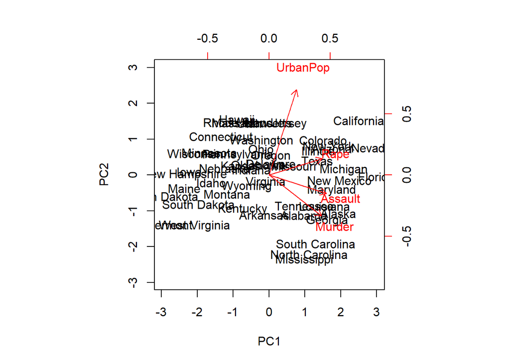

```r
#pca$rotation 을 통해서 각 변수들의 비율을 설명하는 주성분들의 로딩 매트릭스를 확인할 수 있다.
# biplot 그래프를 이용해 pca 결과를 해석해보자. biplot은 각 변수들의 두 개 주성분의 비율을 사용한다.
# 다음 코드는 biplot의 방향을 변경한다. 만약 다음 두 줄의 코드를 포함하지 않으면 그래프는 거울에 비친 것처럼 마주 볼 것이다.
pca$rotation = -pca$rotation
pca$x = -pca$x
biplot(pca, scale=0)
```

biplot 결과 이미지에서 USArrests 데이터 셋의 두 개 주성분 (PC1, PC2)을 확인할 수 있다. 빨간색 화살표는 로딩 벡터로 주성분 벡터를 따라 변수들이 어떻게 분포하는지를 나타낸다.

그래프에서 PC1은 Rape, Assault, Murder 라는 세개의 변수들이 같은 방향으로 근접해 위치하고 있는 것을 볼 수 있다. 이는 이 세개의 변수가 다른 하나인 UrbanPop보다 서로 상관관계가 더 높음을 의미한다. PC2는 UrbanPop에 높은 가중치를 두지만, 다른 나머지 세 개의 변수와 다른 방향에 위치하고 있으므로 상관관계가 낮다.

## 3. 데이터 마이닝 기법

### 3.1 클러스터링 분석

클러스터링 분석(Clustering Analysis)기법은 한 그룹의 객체들을 다른 그룹보다 더 유사한 객체들로 구성해 그룹 짓는 방식으로 **데이터를 그룹화하는 분류기법**이다.

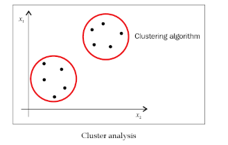

클러스터링 분석은 비지도 학습(Unsupervised learning)기법이다. 회귀분석과 같은 지도학습(Supervised Learning)기법은 입력변수와 반응변수를 가지며, 입력 변수에 통계적 모형을 적용해 반응 변수를 예측한다. 그러나 비지도 학습 기법에는 예측을 위한 어떠한 반응 변수도 존재하지 않으며 오직 입력 변수들만이 존재한다. 그래서 입력 변수가 반응 변수들을 예측하도록 설계하는 대신에 데이터 세트 안에서 특정한 패턴을 찾도록 노력한다. 클러스터링 알고리즘으로는 계층적 클러스터링 분석(Hierarchinal Cluster Analysis), K-평균 클러스터링 분석(K-Means Cluster Analysis), 2단계 클러스터링 분석(Two-Step Cluster Analysis) 등이 널리 알려져 있다.

#### 3.1.1 K-means 클러스터링

K-means 클러스터링은 비지도 학습으로써 데이터로부터 K 개의 클러스터를 갖도록 하는 반복적 알고리즘(Iterative algorithm) 이다.

[output not shown]

위의 두 단계를 모든 데이터 포인트가 두 개 그룹으로 나뉘고 데이터 포인트의 평균값과 중심점이 같아져서 중심점의 이동이 더 이상 없을 때까지 반복한다.

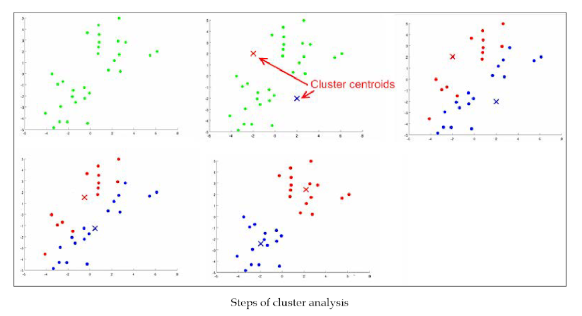

어떻게 클러스터를 구성해나가는가?

**K-평균 클러스터링 R 코드로 구현**

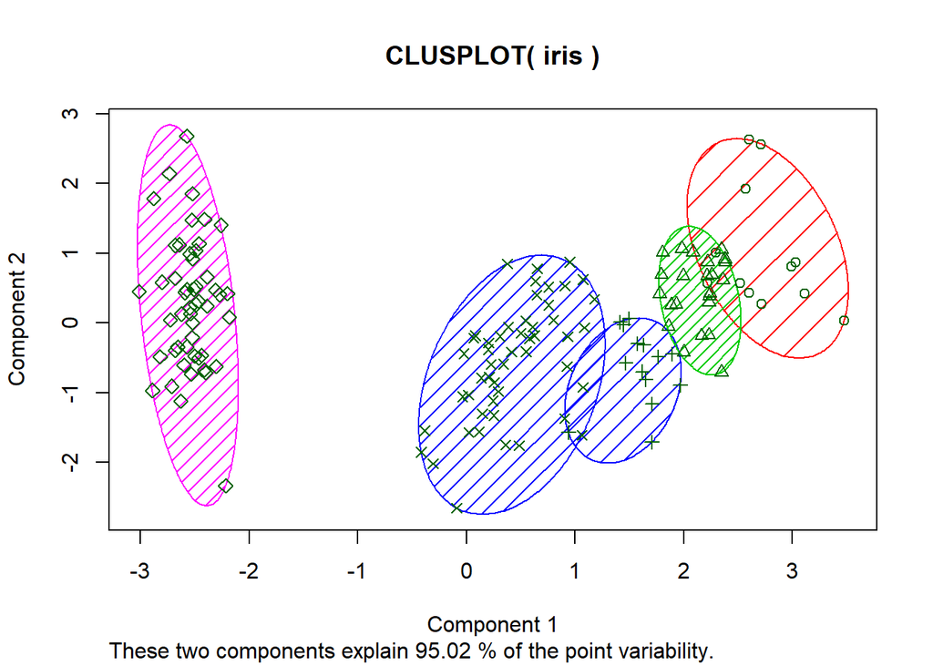

```r
if(! "cluster" %in% rownames(installed.packages())){install.packages("cluster")}
library(cluster)
data(iris)
iris$Species = as.numeric(iris$Species)
kmeans <- kmeans(x=iris, centers=5)
clusplot(iris, kmeans$cluster, color=TRUE, shade = TRUE, labels = 13, lines=0)
```

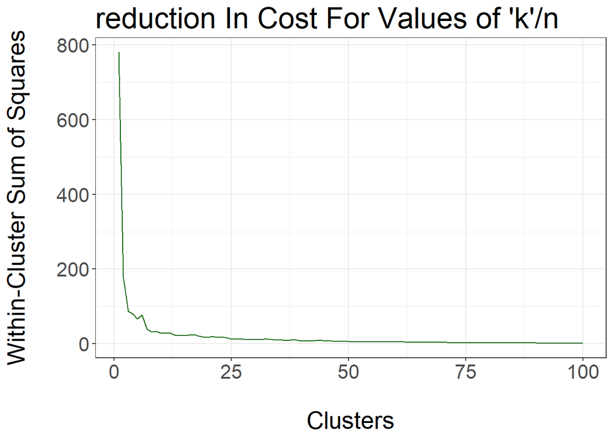

```r
library(cluster)
library(ggplot2)
data(iris)
iris$Species <- as.numeric(iris$Species)
cost_df <- data.frame()
for(i in 1:100){
  kmeans <- kmeans(x=iris, centers=i, iter.max=50)
  cost_df <- rbind(cost_df, cbind(i, kmeans$tot.withinss))
}

names(cost_df) <- c("cluster","cost")
# Elbow 기법으로 유휴한 클러스터의 수를 식별한다.
# 비용 그래프
ggplot(data=cost_df, aes(x=cluster, y=cost, group=1)) +
                    theme_bw(base_family = "Garamond") +
                    geom_line(colour = "darkgreen") +
                    theme(text = element_text(size=20)) +
                    ggtitle("reduction In Cost For Values of 'k'/n") +
                    xlab("\nClusters") +
                    ylab("Within-Cluster Sum of Squares\n")
```

#### 3.1.2 서포트 벡터 머신(SVM)

지도 학습 알고리즘으로 분류 문제를 해결하는 경우 사용되며, 일반적으로 분류 문제를 해결하는데 가장 좋은 알고리즘 중 하나로 여겨진다. 트레이닝 데이터가 두가지 카테고리 중 한 곳에 속하는 구성을 가진다면, SVM 트레이닝 알고리즘은 새로운 입력 값을 어느 한쪽의 카테고리로 할당하는 모델을 생성한다. 이 모델은 데이터들을 각 카테고리의 **데이터들이 경계 지역에 가능한 한 넓은 여백을 갖도록 공간상에 점으로 표현**한 것이며 다음 그림과 같다. 그리고 새로운 데이터들이 입력되면 같은 공간상에서 데이터가 속한 곳의 여백을 기초로 해서 어느 카테고릴에 속하게 되는지 예측한다.

SVM을 p차원의 데이터 셋에 적용할 때 데이터들은 p-1 차원의 초평면상에 표현되며, 알고리즘은 각각의 분류들 사이에 충분한 여백의 공간을 확보하도록 하는 명확한 경계선을 찾아낸다. **최대한의 여백을 갖는 경계선을 찾도록 한다.**

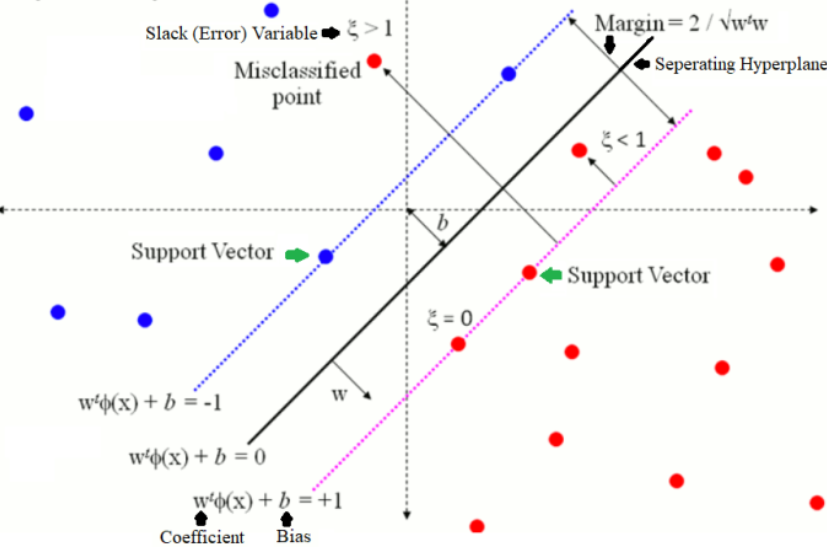

```
- 핵심 사항

    - 무한한 수의 초평면을 생성할 수 있지만, SVM은 최대한의 여백 공간을 갖도록 하는 오직 단 한 개만의 초평면을 선택한다. 다시 말해, 경계를 짓는 초평면은 트레이닝 데이터들로부터 가장 멀리 있는 유일한 초평면이다.

    - 분류기는 오직 초평면의 경계 지역에 위치한 데이터 지점들에만 의존한다. 즉, 위의 그림에서 가는 경계선 및 가장 가까운 데이터와만 관계가 있으며 데이터 셋의 다른 관측치들과는 관계가 없다. 이러한 데이터 점들을 서포트 벡터라 한다.

    - 의사결정 경계는 오직 서포트 벡터에만 영향을 받으며 경계 밖에 위치한 다른 관측치들에는 영향을 받지 않는다. 서포트 벡터가 아닌 데이터의 위치를 변경하더라도 의사결정 경계에는 아무런 영향이 없다. 하지만 서포트 벡터의 위치가 변한다면, 의사결정 경계 역시 달라진다.

    - 트레이닝 데이터의 가장 넓은 여백 공간은 테스트 데이터에서도 테스트 데이터를 정확하게 분리하도록 하는 가장 넓은 여백 공간ㄴ이다.

    - SVM 은 비선형 데이터셋(Non-linear Dataset)에도 잘 작동한다. 이러면 방사형 커널 함수(Radial Kernel Function)를 사용한다.
```

iris를 활용한 e1071 패키지의 SVM 구현

SVM 이 tune 함수 내부에서 호출돼 비용 함수에 다양한 인수 값들을 사용함으로써 교차 검증을 수행하는 것을 볼 수 있다.

교차검증은 아직 보지 못한 데이터에 테스트를 진행하기 전에 예측 모델의 정확도를 평가하기 위해 사용된다.

```r
#SVM
library(e1071)
data(iris)
sample <- iris[sample(nrow(iris)),]
train <- sample[1:105,]
test <- sample[106:150,]
tune <- tune(svm, Species ~., data=train, kernel ="radial", scale=FALSE, ranges = list(cost=c(0.001,0.01,0.1,1,5,10,100)))

tune$best.model
```

```
##
## Call:
## best.tune(method = svm, train.x = Species ~ ., data = train,
##     ranges = list(cost = c(0.001, 0.01, 0.1, 1, 5, 10, 100)),
##     kernel = "radial", scale = FALSE)
##
##
## Parameters:
##    SVM-Type:  C-classification
##  SVM-Kernel:  radial
##        cost:  5
##       gamma:  0.25
##
## Number of Support Vectors:  25
```

```r
summary(tune)
```

```
##
## Parameter tuning of 'svm':
##
## - sampling method: 10-fold cross validation
##
## - best parameters:
##  cost
##     5
##
## - best performance: 0.02909091
##
## - Detailed performance results:
##    cost      error dispersion
## 1 1e-03 0.76909091 0.20310718
## 2 1e-02 0.76909091 0.20310718
## 3 1e-01 0.05636364 0.04863613
## 4 1e+00 0.03909091 0.05053433
## 5 5e+00 0.02909091 0.04690612
## 6 1e+01 0.02909091 0.04690612
## 7 1e+02 0.05727273 0.04943204
```

**tune$best.model 객체를 통해 가장 좋은 성능을 발휘할 때의 비용 함수의 인수와 총 서포트 벡터의 수를 알 수 있다.**

다음의 코드로 모델을 만들고 model <- svm(Species~., data=train, kernel=“radial”, cost= , scale=FALSE)

cost부분에 tune$best.model 을 통해 알게된 비용 함수의 인수를 선택하면 된다.

다음의 코드를 통해 예측을 한 결과를 알 수 있다. predict(model, test)

### 3.2 의사결정나무(Decision Tree)

의사결정나무는 간단하고 빠르며 트리 구조 형태의 지도 학습 알고리즘으로 분류 문제를 해결하는 알고리즘이다. 이 알고리즘은 다른 로지스틱 회귀분석(Logistic Regression) 방법들에 비해 다소 성능이 낮음에도 불구하고 추천 시스템을 다룰 때 꽤 쓸모가 있다.

데이터를 더는 논리적으로 분류할 수 없을때까지 계속해서 수행한다.

**tree 패키지를 통한 의사결정나무를 구현하는 R코드**

```r
library(tree)
sample <- iris[sample(nrow(iris)),]
train <- sample[1:105,]
test <- sample[106:150,]
model <- tree(Species~., train)
summary(model)
```

```
##
## Classification tree:
## tree(formula = Species ~ ., data = train)
## Variables actually used in tree construction:
## [1] "Petal.Length" "Sepal.Length"
## Number of terminal nodes:  5
## Residual mean deviance:  0.1214 = 12.14 / 100
## Misclassification error rate: 0.02857 = 3 / 105
```

단말 노드(terminal node)의 개수, 잔차 분산의 평균, 오분류율을 알 수있다.

의사결정나무 표 그리기

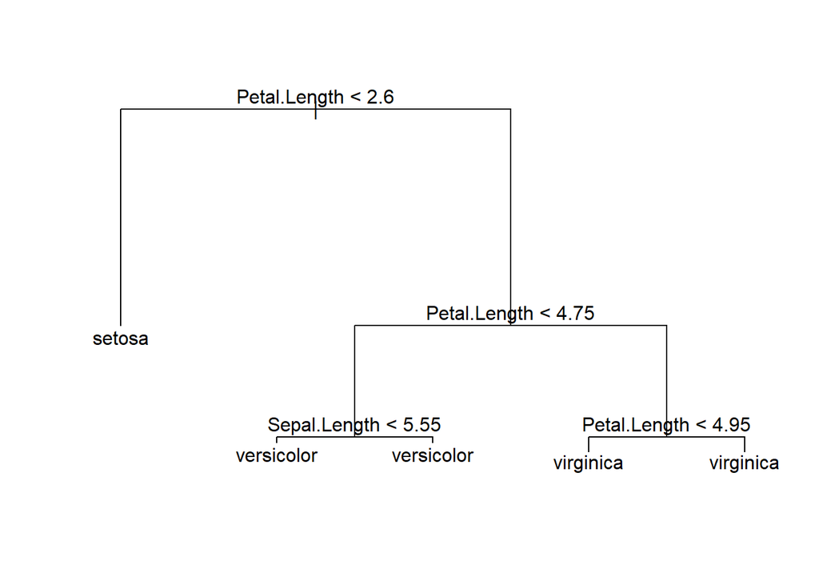

```r
plot(model)
text(model)
```

```r
pred <- predict(model, test[,-5],type="class")
pred
```

```
##  [1] versicolor virginica  setosa     virginica  setosa     versicolor
##  [7] setosa     setosa     virginica  virginica  versicolor virginica
## [13] setosa     versicolor virginica  setosa     virginica  versicolor
## [19] versicolor virginica  versicolor setosa     versicolor virginica
## [25] versicolor setosa     setosa     setosa     setosa     setosa
## [31] virginica  versicolor virginica  virginica  virginica  setosa
## [37] versicolor versicolor virginica  virginica  setosa     versicolor
## [43] versicolor versicolor versicolor
## Levels: setosa versicolor virginica
```

test 셋을 tree 함수가 의사결정나무 알고리즘을 통해 예측한 결과(classification 형태)를 보여준다

### 3.3 앙상블 기법

다양한 통계적 문제를 해결하는 과정에서 더 나은 예측 성능을 위해 단일의 학습 모델을 적용하기보다는 다양한 학습 모델을 사용하는 것이다. 여기서는 배깅, 부스팅, 랜덤포레스트와 같은 널리 알려진 앙상블 기법들을 본다.

#### 3.3.1 배깅

배깅(bagging)은 Bootstrap Aggregating 의 준말로 머신러닝 알고리즘의 안정성과 정확도를 향상하기 위해 설계됐다. 배깅 기법은 오버피팅(Overffiting)을 피하고, 알고리즘의 안정성을 높일 목적으로 사용되며 주로 의사결정 나무와 함께 사용된다.

배깅은 데이터 셋으로부터 부트스트랩(Bootstrap)해서 샘플 데이터를 임의로 생성하는 과정과 각각의 모델들을 트레이닝하는 과정을 동반한다. 그 후 모든 반응 변수를 집계(Aggregating)하는 과정과 평균화(Averaging)하는 과정을 통해 예측을 진행한다.

```
    - i=1 ... n 인n 개의 데이터를 포함하는 데이터 셋(Xi, Yi)를 가정해본다.

    - 이제 부트스트랩 기법을 사용해 원시 데이터로부터 B 샘플을 복원 추출한다.

    - 다음으로 B 샘플을 회귀분석이나 분류 모델로 각각 트레이닝 한다. 그리고 회귀분석의 경우 생성된 모델들의 결과 값들은 평균화 과정을 걸쳐 테스트 데이터 셋으로 예측을 진행한다. 또한 분류 문제의 경우 B 샘플 중 가장 빈번하게 나타나는 모델을 선택해 진행한다.
```

#### 3.3.2 랜덤 포레스트

지도학습 알고리즘으로 배깅과 비슷한 형태로 설계되지만, 그보다는 간단하게 사용할 수 있는 방법이다. 배깅에서 부트스트랩 기법을 사용해 생성된 B 새플의 전체 변수를 사용하는 것과 달리, 랜덤 포레스트에서는 B 샘플들 각각의 전체 변수 중 임의의 적은 수의 예측 변수들만을 선택해 사용한다. 이렇게 선택된 변수들은 모델을 트레이닝하는 데 사용된다. 각 샘플의 예측 변수 개수는 m=sqrt(p)(단 p는 원시데이터의 전체 변수의 수.) 의 식으로 결정된다.

```
- 랜덤 포레스트의 중요한 부분

    - 이러한 접근 방식은 매 연산 시 모든 변수를 사용하는 것 대신에 데이터 셋에서 의도적으로 일부 변수들을 선택함으로써 일부 주요 예측 변수들에 큰 영향력을 미치는 문제를 감소시킨다.

    - 또한 이 접근 방식은 변수들 간의 상관관계를 완화해 변동성을 낮추고 모델의 안정성을 높일 수 있다.
```

**randomForest 패키지와 iris 데이터를 활용한 랜덤 포레스트 구현 R 소스 코드**

```r
#randomForest
library(randomForest)
data(iris)
sample <- iris[sample(nrow(iris)),]
train <- sample[1:105,]
test <- sample[106:150,]
model <- randomForest(Species~., data=train, mtry=2, importance=TRUE, proximity=TRUE)
model
```

```
##
## Call:
##  randomForest(formula = Species ~ ., data = train, mtry = 2, importance = TRUE,      proximity = TRUE)
##                Type of random forest: classification
##                      Number of trees: 500
## No. of variables tried at each split: 2
##
##         OOB estimate of  error rate: 6.67%
## Confusion matrix:
##            setosa versicolor virginica class.error
## setosa         36          0         0  0.00000000
## versicolor      0         31         3  0.08823529
## virginica       0          4        31  0.11428571
```

**randomForest 함수속 옵션**

ntree= 나무의 개수. mtry = 노드를 나눌 기준을 정할 때 고려할 변수의 수 importance = 변수의 중요도 평가 여부

```r
pred <- predict(model, newdata = test[,-5])
pred
```

```
##         77         10          3        136        126         76
## versicolor     setosa     setosa  virginica  virginica versicolor
##          5        149        140        143         82         16
##     setosa  virginica  virginica  virginica versicolor     setosa
##         99        102         64        125         56        121
## versicolor  virginica versicolor  virginica versicolor  virginica
##         29         91        138        141         87         13
##     setosa versicolor  virginica  virginica versicolor     setosa
##        105         50          6         93         45         94
##  virginica     setosa     setosa versicolor     setosa versicolor
##        133         35        146         43         62          4
##  virginica     setosa  virginica     setosa versicolor     setosa
##         20         81         75        111         61         86
##     setosa versicolor versicolor  virginica versicolor versicolor
##         78         25        131
##  virginica     setosa  virginica
## Levels: setosa versicolor virginica
```

45개의 테스트 데이터를 예측한 결과를 알 수있다.

#### 3.3.3 부스팅

여러 개의 부트스트랩 샘플들을 생성하는 배깅 기법과는 다르게 **데이터 셋에 적합한 새로운 모델들이 만들어지고, 그 후 각각의 모든 모델을 결합해 하나의 예측 모델을 생성**한다. 이 때 새 모델은 이전 모델의 정보를 활용해 생성되며 부스팅은 다음의 두 가지 단계를 포함하는 반복적 기법으로 이해될 수 있다.

```
    - 새로운 모델은 반응 변수 대신 이전 모델의 오차율에 기반을 두고 생성된다.

    - 오차는 해당 단계의 모델에서 계산되고 이전 단계의 모델에 반영한다.
```

위의 두 단계는 계속해서 반복되며 각각의 새로운 모델들은 이전 단계의 오차를 통해 학습함으로써 **궁극적으로 모델의 정확도를 향상**시킨다.

**R 코드로 구현하는 부스팅**

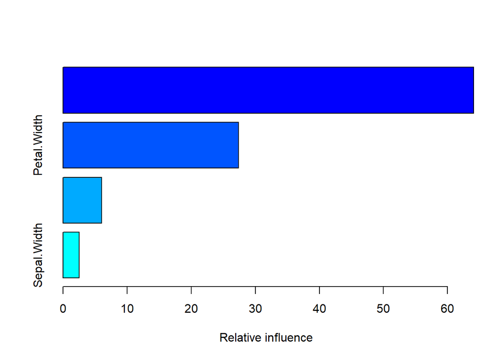

```
##                       var  rel.inf
## Petal.Length Petal.Length 64.06422
## Petal.Width   Petal.Width 27.39754
## Sepal.Length Sepal.Length  6.02442
## Sepal.Width   Sepal.Width  2.51382
```

```r
if(! "gbm" %in% rownames(installed.packages())){install.packages("gbm")}
library(gbm)
sample <- iris[sample(nrow(iris)),]
train <- sample[1:105,]
test <- sample[106:150,]
model <- gbm(Species~., data=train, distribution="multinomial", n.trees=5000, interaction.depth=4)
summary(model)
```

**위의 요약 내용은 모델의 변수들이 가지는 상대적인 중요성을 나타낸다.** Petal 이 Sepal보다 상대적으로 중요하구나 !?

예측

```r
pred <- predict(model, newdata = test[,-5], n.trees = 5000)
pred[1:5,,]
```

```
##         setosa versicolor virginica
## [1,] -472.5625  -373.1391 -428.9018
## [2,] -494.7574  -302.5836 -424.4282
## [3,] -484.3309  -304.2452 -420.8394
## [4,] -499.4633  -430.4815 -252.6713
## [5,] -335.7248  -436.5774 -491.9152
```

apply(.., 1, which.max) 함수를 실행해 pred 매트릭스로부터 가장 높은 확률을 가진 응답으로 선택한다.

```r
p.pred <- apply(pred, 1, which.max)
p.pred
```

```
##  [1] 2 2 2 3 1 2 1 3 1 3 2 1 1 1 2 2 3 3 1 2 3 2 3 3 1 1 3 2 1 3 3 1 1 3 3
## [36] 3 2 2 3 1 1 1 3 3 1
```

**값이 높은 것이 가장 높은 확률을 가진 응답인가 보지..?** 어쨌든 예측 결과.

### 3.4 데이터 마이닝 알고리즘 평가

모든 데이터 분석 모델들의 궁극적인 목표는 추후 입력될 데이터들에 대해 잘 작동하는 것이다. 이러한 목표는 오직 개발 단계에서 모델을 효율적이고 강건하게 만들 때만 가능할 것이다.

데이터 분석 모델을 평가하면서 고려해야할 가장 중요한 점

```
    - 모델이 오버피팅(Overfitting), 언더피팅(Underfitting) 됐는지 확인한다.

    - 모델이 얼마나 추후 입력될 데이터들과 테스트 데이터에서 잘 작동하는지를 확인한다.
```

바이어스(Bias, 편향)라고도 불리는 언더피팅은 생성한 모델이 트레이닝 데이터에서조차도 잘 작동하지 않은 경우로, 데이터에 적합한 정도가 낮은 모델을 적용하게 되는 것을 의미한다.

예를 들어 데이터가 비선형적으로 분포돼 있고 그러한 데이터에 선형 모델을 적용하는 것이다. 다음 그림은 데이터가 비선형적으로 분포된 것을 확인할 수 있다. 이러한 데이터에 선형 모델(에메랄드색 선)을 적용하게 된다면 모델의 예측력은 매우 낮을 것이다.

오버피팅은 모델이 트레이닝 데이터에서는 잘 작동하지만, 실제 테스트 데이터에서는 잘 작동하지 않는 경우를 말한다. 이러한 경우는 모델이 데이터로부터 학습하기 보다는 데이터의 패턴을 기억할 때 발생한다.

예를 들어 데이터가 비선형적으로 분포되어 있을 때 모든 데이터를 고려한 복잡한 형태의 모델이 적용 된다면 데이터 분포 자체와 매우 흡사하므로 이전에 다루지 않았던 새로운 형태의 데이터에서는 좋은 성능을 내지 못하게 된다.

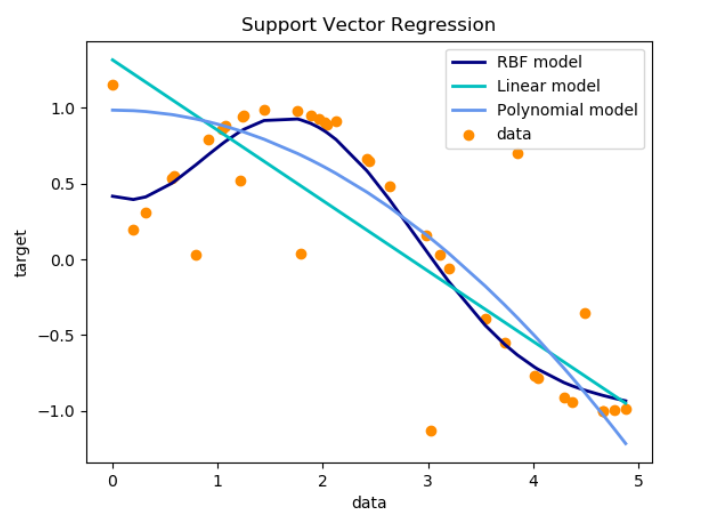

오버피팅과 언더피팅

파란색 선 처럼 적절하게 생성된모델을 볼 수 있다.

오버피팅과 언더피팅을 피하고자 교차검증(Cross validation), 정규화(Regularization), 가지치기(Pruning), 모델 비교(Model Comparison), ROC 곡선, 혼동 매트릭스 등을 활용해 생성한 모델을 평가한다.

**교차검증** : 대부분의 모델에서 사용되는 가장 널리 알려진 모델 평가 기법으로 데이터를 트레이닝, 테스트 셋으로 나눈 후, 트레이닝 셋을 활용하여 모델을 생성한다. 그 후 테스트 셋에 적용하여 매 테스트 단계에서 에러율을 계산하고 반복 절차가 끝나면 에러율의 평균을 이용해 모델의 정확도를 일반화 한다.

**정규화** : 비용 함수를 최소화하려는 목적으로 모델의 복잡성을 낮추기 위해 변수들에 불이익을 준다. 릿지 회귀(Ridge regression)와 라소 회귀(Lasso regression)가 가장 널리 알려진 정규화 기법들이다. 이 두 기법들 모두 변수의 계수들을 0에 가깝게 만들려 노력하며 적은 수의 변수들을 사용할 때 데이터에 더 적합한 모델이 된다.

**혼동 매트릭스(Confusion Matrix)** : 분류 모델의 성능을 평가하는 데 널리 사용된다. 모델의 결과를 사용해 혼동 매트릭스를 생성하며, 그 결과 값들을 이용해 모델을 평가하기 위한 재현력/민감도/특이도 등의 지표들을 계산한다.

**정확도(Precision)**: 양성으로 예측한 것 중 실제 양성인 것의 비율(TP/TP+FP)

**재현력(Recall) 또는 민감도(Sensitivity)** : 실제 양성인 것들 중 양성으로 예측한 것의 비율(TP/TP+TN)

**특이도(Specificity)** : 실제 음성인 것들 중 음성으로 예측 성공한 것의 비율(TN/TN+FP )

**모델 비교**: 분류 문제는 한 개 혹은 그 이상의 통계적 모형으로 해결할 수 있다. 예를 들어 하나의 문제를 로지스틱 회귀분석, 의사결정나무, 앙상블 기법, SVM 등의 다양한 방법으로 해결할 수 있다.

어떤 모델이 적합한지를 판단하는 기준으로는 아카이케 정보 기준(AIC, Akaike information criteria), 베이지안 정보 기준(BIC, Bayesian information criteria), 수정된 R^2(Adjusted R^2) 과 같이 다양한 형태의 접근 방식들이 존재하며, 각 모델의 AIC, BIC, R^2 값들을 계산해 최적의 모델을 선택한다.

**교재. Building a Recommendation System with R

**저자. Suresh K. Gorakala, Michele Usuelli